# Travel the World with Homework 2

Author

Traveling the world is fun! You will use a few different resources to help you decide some exciting destinations to visit.

## General Tips

This is very much a step-by-step process. Don’t go crazy trying to get everything done with as few lines as possible. Read the documentation for the AlphaVantage api! Carefully explore all html pages. There isn’t a need to get too fancy with anything here – just go with simple functions and all should be good. **Don’t print comments**, but use normal text for explanations.

## Step 1

```python
import glob as glob
import pandas as pd

files=glob.glob("/Users/totoh/Desktop/Unstructured Data/homework2/country_info/*.txt")

data = []
for file in files:
    with open(file, 'r') as f:
        parts = file.split('/')[-1].replace('.txt', '').split('_')
        data.append({
            'country': parts[0],
            'info_type': parts[1],
            'content': f.read()
        })

df = pd.DataFrame(data)
df
```

|  | country | info_type | content |
| --- | --- | --- | --- |
| 0 | aruba | background | Discovered and claimed for Spain in 1499, Arub... |
| 1 | aruba | etymology | The name Aruba most likely came from the Caque... |
| 2 | samoa | etymology | Samoa may come from Samoan: Sāmoa, lit. 'holy ... |
| 3 | samoa | background | The first Austronesian settlers arrived in Sam... |

## Step 2

Use the CIA’s World Factbook **country travel sheets** to produce a data frame with every country’s name, major languages, driving direction, cuisine, and one other feature of your choosing. The Factbook is available here: https://www.cia.gov/the-world-factbook/

```python
import requests
from bs4 import BeautifulSoup
import time
import numpy as np
import pandas as pd

link = "https://web.archive.org/web/20260203121052/https://www.cia.gov/the-world-factbook/countries/"

response = requests.get(link)
soup = BeautifulSoup(response.content, 'html.parser')

sitemap = requests.get('https://web.archive.org/web/20260203121052/https://www.cia.gov/the-world-factbook/sitemap/sitemap-0.xml')
sitemap_soup = BeautifulSoup(sitemap.text, 'xml')

all_urls = [loc.get_text() for loc in sitemap_soup.select('loc')]
country_urls = [url for url in all_urls if '/countries/' in url and '/travel-facts/' in url]

json_links = ['https://web.archive.org/web/20260203121052/' + country_urls[i].replace('/countries/', '/page-data/countries/').replace('/travel-facts/', '/travel-facts/page-data.json') for i in range(len(country_urls))]

travel_list = []

for url in json_links:
    try:
        response = requests.get(url)
        data = response.json()['result']['data']['travelFact']

        country = data['placeName']
        values = data['values']

        lang = ''
        driving = ''
        cuisine = ''
        religion = ''

        for item in values:
            if item['attribute'] == 'majorLanguages':
                language = item['value']
            if item['attribute'] == 'roadDrivingSide':
                driving = item['value']
            if item['attribute'] == 'traditionalCuisine':
                cuisine = item['value']
            if item['attribute'] == 'religions':
                religion = item['value']

        travel_list.append([country, language, driving, cuisine, religion])

    except:
        continue


travel_pd = pd.DataFrame(travel_list, columns=['country', 'languages', 'driving_side', 'cuisine', 'religion'])

travel_pd['driving_side'] = travel_pd['driving_side'].str.replace('<.*?>', '', regex=True)
travel_pd['cuisine'] = travel_pd['cuisine'].str.replace('<.*?>', '', regex=True)
travel_pd['languages'] = travel_pd['languages'].str.replace('<.*?>', '', regex=True)
travel_pd['religion'] = travel_pd['religion'].str.replace('<.*?>', '', regex=True)

travel_pd
print(values)
```

[output not shown]

## Step 3

We want just the right amount of adventure to our travel, so use the State Department’s **Travel Advisories** page to get a data frame with every country’s name and travel advisory level. The travel advisories are available here: https://travel.state.gov/en/international-travel/travel-advisories.html. What are the most common Risk Indicators? What patterns do you see in terms of countries with high travel advisory levels?

```python
import requests
from bs4 import BeautifulSoup
import time
import numpy as np
import pandas as pd

link = "https://travel.state.gov/en/international-travel/travel-advisories.html"

response = requests.get(link)
soup = BeautifulSoup(response.content, 'html.parser')
table = soup.find("table")
tbody=table.find("tbody")
rows=tbody.find_all("tr")

data = []

for row in rows:
    try:
        destination = row.find("th").get_text(strip=True)
        level = row.find("td").get_text(strip=True)

        cells = row.find_all("td")
        risk_cell = cells[1]
        risk_spans = risk_cell.find_all("span")
        risks = [r.get_text(strip=True) for r in risk_spans]
        risk_text = ", ".join(risks)

        data.append([destination, level, risk_text])

    except:
        continue

df_advisory = pd.DataFrame(
    data,
    columns=["country", "level", "risk_indicators"]
)

df_advisory

risk_split = df_advisory["risk_indicators"].str.split(", ")
risk_exploded = risk_split.explode()
risk_counts = risk_exploded.value_counts()
risk_counts

#Crime is the most frequently listed risk indicator across countries

high_risk_df = df_advisory[
    df_advisory["level"].str.contains("Level 3|Level 4")
]

high_risk_df["risk_list"] = high_risk_df["risk_indicators"].str.findall(
    r"[A-Z\s]+(?=\s*\()"
)

high_risk_df

#The main patterns are that unrest appears very frequently, terrorism is also common, and many of the highest advisory countries are clustered in the Middle East.
```

|  | country | level | risk_indicators | risk_list |
| --- | --- | --- | --- | --- |
| 0 | Afghanistan | Level 4: Do not travel | UNREST (U), CRIME (C), HEALTH (H), KIDNAPPING ... | [UNREST , CRIME , HEALTH , KIDNAPPING OR HO... |
| 16 | Bangladesh | Level 3: Reconsider travel | UNREST (U), CRIME (C), KIDNAPPING OR HOSTAGE T... | [UNREST , CRIME , KIDNAPPING OR HOSTAGE TAKI... |
| 18 | Belarus | Level 4: Do not travel | UNREST (U), OTHER (O) | [UNREST , OTHER ] |
| 33 | Burkina Faso | Level 4: Do not travel | CRIME (C), KIDNAPPING OR HOSTAGE TAKING (K), T... | [CRIME , KIDNAPPING OR HOSTAGE TAKING , TERR... |
| 34 | Burma (Myanmar) | Level 4: Do not travel | UNREST (U), CRIME (C), HEALTH (H), WRONGFUL DE... | [UNREST , CRIME , HEALTH , WRONGFUL DETENTI... |
| 35 | Burundi | Level 3: Reconsider travel | UNREST (U), CRIME (C), HEALTH (H) | [UNREST , CRIME , HEALTH ] |
| 41 | Central African Republic | Level 4: Do not travel | UNREST (U), CRIME (C), HEALTH (H), KIDNAPPING ... | [UNREST , CRIME , HEALTH , KIDNAPPING OR HO... |
| 42 | Chad | Level 3: Reconsider travel | UNREST (U), CRIME (C), KIDNAPPING OR HOSTAGE T... | [UNREST , CRIME , KIDNAPPING OR HOSTAGE TAKI... |
| 45 | Colombia | Level 3: Reconsider travel | UNREST (U), CRIME (C), KIDNAPPING OR HOSTAGE T... | [UNREST , CRIME , KIDNAPPING OR HOSTAGE TAKI... |
| 54 | Democratic Republic of the Congo (D.R.C.) | Level 3: Reconsider travel | UNREST (U), CRIME (C), KIDNAPPING OR HOSTAGE T... | [UNREST , CRIME , KIDNAPPING OR HOSTAGE TAKI... |
| 66 | Ethiopia | Level 3: Reconsider travel | UNREST (U), CRIME (C), KIDNAPPING OR HOSTAGE T... | [UNREST , CRIME , KIDNAPPING OR HOSTAGE TAKI... |
| 77 | Gaza | Level 4: Do not travel | TERRORISM (T), OTHER (O) | [TERRORISM , OTHER ] |
| 87 | Guatemala | Level 3: Reconsider travel | CRIME (C) | [CRIME ] |
| 89 | Guinea-Bissau | Level 3: Reconsider travel | UNREST (U), HEALTH (H), OTHER (O) | [UNREST , HEALTH , OTHER ] |
| 90 | Guyana | Level 3: Reconsider travel |  | [] |
| 91 | Haiti | Level 4: Do not travel | UNREST (U), CRIME (C), HEALTH (H), KIDNAPPING ... | [UNREST , CRIME , HEALTH , KIDNAPPING OR HO... |
| 92 | Honduras | Level 3: Reconsider travel | CRIME (C) | [CRIME ] |
| 98 | Iran | Level 4: Do not travel | UNREST (U), KIDNAPPING OR HOSTAGE TAKING (K), ... | [UNREST , KIDNAPPING OR HOSTAGE TAKING , TER... |
| 99 | Iraq | Level 4: Do not travel | UNREST (U), KIDNAPPING OR HOSTAGE TAKING (K), ... | [UNREST , KIDNAPPING OR HOSTAGE TAKING , TER... |
| 102 | Israel | Level 3: Reconsider travel | UNREST (U), TERRORISM (T) | [UNREST , TERRORISM ] |
| 103 | Israel, The West Bank and Gaza | Level 3: Reconsider travel | UNREST (U), TERRORISM (T), OTHER (O) | [UNREST , TERRORISM , OTHER ] |
| 107 | Jerusalem | Level 3: Reconsider travel | UNREST (U), TERRORISM (T), OTHER (O) | [UNREST , TERRORISM , OTHER ] |
| 117 | Lebanon | Level 4: Do not travel | UNREST (U), CRIME (C), KIDNAPPING OR HOSTAGE T... | [UNREST , CRIME , KIDNAPPING OR HOSTAGE TAKI... |
| 120 | Libya | Level 4: Do not travel | UNREST (U), CRIME (C), KIDNAPPING OR HOSTAGE T... | [UNREST , CRIME , KIDNAPPING OR HOSTAGE TAKI... |
| 129 | Mali | Level 4: Do not travel | CRIME (C), KIDNAPPING OR HOSTAGE TAKING (K), T... | [CRIME , KIDNAPPING OR HOSTAGE TAKING , TERR... |
| 133 | Mauritania | Level 3: Reconsider travel | CRIME (C), TERRORISM (T) | [CRIME , TERRORISM ] |
| 145 | Nepal | Level 3: Reconsider travel | UNREST (U) | [UNREST ] |
| 147 | New Caledonia | Level 3: Reconsider travel | UNREST (U), CRIME (C) | [UNREST , CRIME ] |
| 149 | Nicaragua | Level 3: Reconsider travel | CRIME (C), HEALTH (H), WRONGFUL DETENTION (D),... | [CRIME , HEALTH , WRONGFUL DETENTION , OTHER ] |
| 150 | Niger | Level 4: Do not travel | UNREST (U), CRIME (C), HEALTH (H), KIDNAPPING ... | [UNREST , CRIME , HEALTH , KIDNAPPING OR HO... |
| 151 | Nigeria | Level 3: Reconsider travel | UNREST (U), CRIME (C), KIDNAPPING OR HOSTAGE T... | [UNREST , CRIME , KIDNAPPING OR HOSTAGE TAKI... |
| 152 | North Korea (Democratic People's Republic of K... | Level 4: Do not travel | WRONGFUL DETENTION (D), OTHER (O) | [WRONGFUL DETENTION , OTHER ] |
| 155 | Pakistan | Level 3: Reconsider travel | TERRORISM (T), UNREST (U), CRIME (C), KIDNAPPI... | [TERRORISM , UNREST , CRIME , KIDNAPPING OR... |
| 158 | Papua New Guinea | Level 3: Reconsider travel | UNREST (U), CRIME (C), HEALTH (H), KIDNAPPING ... | [UNREST , CRIME , HEALTH , KIDNAPPING OR HO... |
| 168 | Russia | Level 4: Do not travel | UNREST (U), TERRORISM (T), WRONGFUL DETENTION ... | [UNREST , TERRORISM , WRONGFUL DETENTION , ... |
| 190 | Somalia | Level 4: Do not travel | UNREST (U), CRIME (C), KIDNAPPING OR HOSTAGE T... | [UNREST , CRIME , KIDNAPPING OR HOSTAGE TAKI... |
| 193 | South Sudan | Level 4: Do not travel | CRIME (C), KIDNAPPING OR HOSTAGE TAKING (K), O... | [CRIME , KIDNAPPING OR HOSTAGE TAKING , OTHE... |
| 196 | Sudan | Level 4: Do not travel | UNREST (U), CRIME (C), KIDNAPPING OR HOSTAGE T... | [UNREST , CRIME , KIDNAPPING OR HOSTAGE TAKI... |
| 200 | Syria | Level 4: Do not travel | UNREST (U), CRIME (C), KIDNAPPING OR HOSTAGE T... | [UNREST , CRIME , KIDNAPPING OR HOSTAGE TAKI... |
| 203 | Tanzania | Level 3: Reconsider travel | CRIME (C), TERRORISM (T), OTHER (O), UNREST (U) | [CRIME , TERRORISM , OTHER , UNREST ] |
| 209 | Trinidad and Tobago | Level 3: Reconsider travel | CRIME (C), KIDNAPPING OR HOSTAGE TAKING (K), T... | [CRIME , KIDNAPPING OR HOSTAGE TAKING , TERR... |
| 215 | Uganda | Level 3: Reconsider travel | UNREST (U), CRIME (C), TERRORISM (T), OTHER (O) | [UNREST , CRIME , TERRORISM , OTHER ] |
| 216 | Ukraine | Level 4: Do not travel | OTHER (O) | [OTHER ] |
| 223 | Venezuela | Level 4: Do not travel | UNREST (U), CRIME (C), HEALTH (H), KIDNAPPING ... | [UNREST , CRIME , HEALTH , KIDNAPPING OR HO... |
| 225 | West Bank | Level 3: Reconsider travel | TERRORISM (T), OTHER (O) | [TERRORISM , OTHER ] |
| 226 | Yemen | Level 4: Do not travel | UNREST (U), CRIME (C), HEALTH (H), KIDNAPPING ... | [UNREST , CRIME , HEALTH , KIDNAPPING OR HO... |

## Step 4

Use the AlphaVantage api (FX_Daily at https://www.alphavantage.co/documentation/) to get daily exchange rates for the US and 3 other countries of your choosing. You cannot use any AlphaVantage packages (i.e., you can only use requests to grab the data). Tell me about the general trend that you are seeing. I don’t care which viz package you use (e.g., seaborn, plotnine, plotly).

```python
import requests
import time
import pandas as pd

currencies = ['JPY', 'CNY', 'CHF']

fx_list = []

for currency in currencies:

    time.sleep(15)

    url = f'https://www.alphavantage.co/query?function=FX_DAILY&from_symbol=USD&to_symbol={currency}&outputsize=full&apikey=YOUR_API_KEY'

    response = requests.get(url)
    data = response.json()

    ts = data['Time Series FX (Daily)']

    for date in ts:
        close_price = float(ts[date]['4. close'])
        fx_list.append([date, currency, close_price])

fx_df = pd.DataFrame(fx_list, columns=['date', 'currency', 'close'])


fx_df['date'] = pd.to_datetime(fx_df['date'])


fx_df = fx_df.sort_values('date')

fx_df
```

|  | date | currency | close |
| --- | --- | --- | --- |
| 9999 | 2006-07-03 | CNY | 7.9982 |
| 9998 | 2006-07-04 | CNY | 7.9910 |
| 9997 | 2006-07-05 | CNY | 7.9955 |
| 9996 | 2006-07-06 | CNY | 7.9896 |
| 9995 | 2006-07-07 | CNY | 7.9839 |
| ... | ... | ... | ... |
| 10001 | 2026-02-16 | CHF | 0.7693 |
| 5001 | 2026-02-16 | CNY | 6.9080 |
| 0 | 2026-02-16 | JPY | 153.5100 |
| 10000 | 2026-02-17 | CHF | 0.7697 |
| 5000 | 2026-02-17 | CNY | 6.9080 |

15000 rows × 3 columns

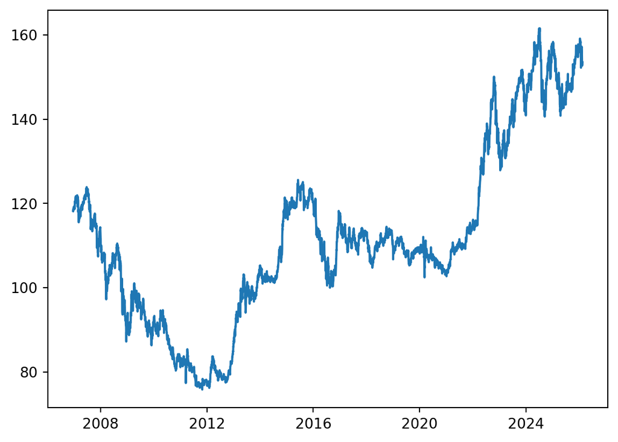

```python
import matplotlib.pyplot as plt

jpy = fx_df[fx_df["currency"] == "JPY"]

plt.figure()
plt.plot(jpy["date"], jpy["close"])
plt.show()
```

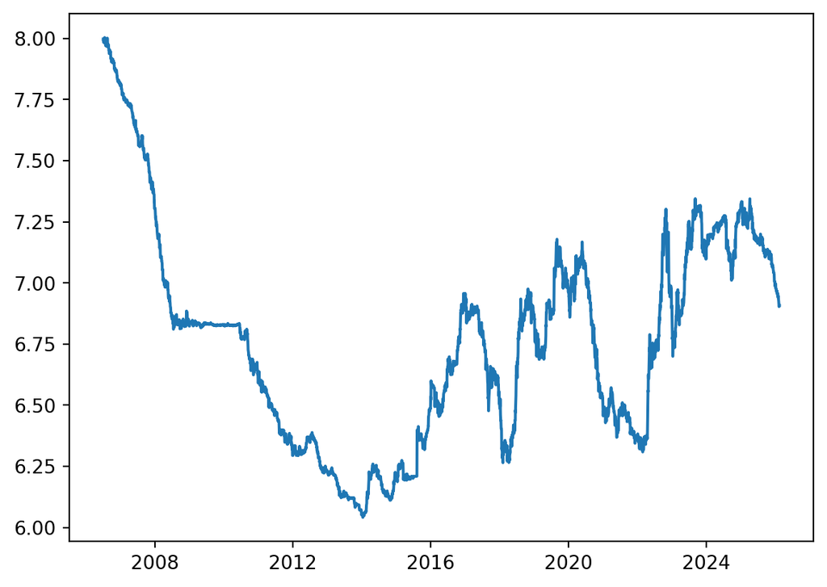

```python
jpy = fx_df[fx_df["currency"] == "CNY"]

plt.figure()
plt.plot(jpy["date"], jpy["close"])
plt.show()
```

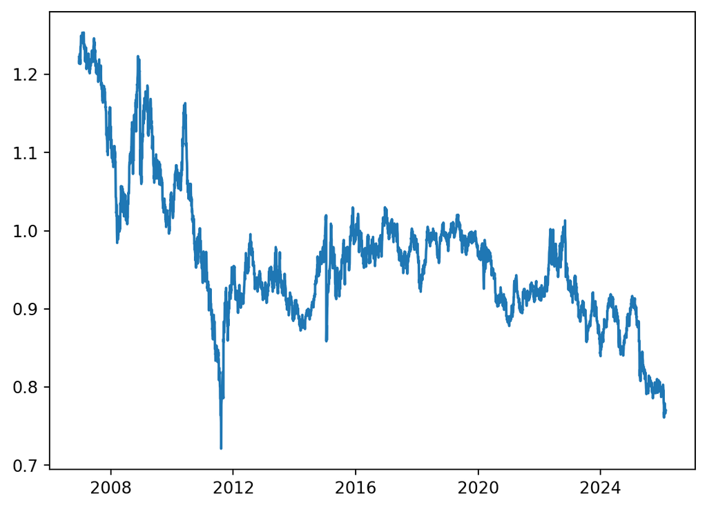

```python
jpy = fx_df[fx_df["currency"] == "CHF"]

plt.figure()
plt.plot(jpy["date"], jpy["close"])
plt.show()
```

## Step 5

With all of this work out of the way, we can start getting down to strategy. Based upon the data that you’ve collected, what countries would you recommend visiting and why?

```python
#In recent years, the dollar has strengthened significantly against the Japanese yen, making Japan more affordable for American travelers, and since Japan also has a low travel advisory level, it offers the best overall value when considering both exchange rates and safety
```